# hw2

# Домашняя работа 2

## Загрузка и очистка данных

```r
data = read.csv("https://raw.githubusercontent.com/SergeyMirvoda/da2016/master/data/calif_penn_2011.csv")
```

Количество строк

```r
nrow(data)
```

```
## [1] 11275
```

Количество столбцов

```r
ncol(data)
```

```
## [1] 34
```

Выполните следующую команду

```r
colSums(apply(data,c(1,2), is.na))
```

```
##                           X                     GEO.id2
##                           0                           0
##                     STATEFP                    COUNTYFP
##                           0                           0
##                     TRACTCE                  POPULATION
##                           0                           0
##                    LATITUDE                   LONGITUDE
##                           0                           0
##           GEO.display.label          Median_house_value
##                           0                         599
##                 Total_units                Vacant_units
##                           0                           0
##                Median_rooms  Mean_household_size_owners
##                         157                         215
## Mean_household_size_renters         Built_2005_or_later
##                         152                          98
##          Built_2000_to_2004                 Built_1990s
##                          98                          98
##                 Built_1980s                 Built_1970s
##                          98                          98
##                 Built_1960s                 Built_1950s
##                          98                          98
##                 Built_1940s       Built_1939_or_earlier
##                          98                          98
##                  Bedrooms_0                  Bedrooms_1
##                          98                          98
##                  Bedrooms_2                  Bedrooms_3
##                          98                          98
##                  Bedrooms_4          Bedrooms_5_or_more
##                          98                          98
##                      Owners                     Renters
##                         100                         100
##     Median_household_income       Mean_household_income
##                         115                         126
```

Проверяются все столбцы на появление значения NA и выводится количество этих значений

Создание нового фрейма без значений NA

```r
new = na.omit(data)
```

```r
nrow(data) - nrow(new)
```

```
## [1] 670
```

670 строк было удалено, результат не соответствует, однако это объясняется наличием нескольких NA в одной строке

## Новые дома

Построение диаграммы рассеяния (scatterplot) медианы стоимости домов (переменная Median_house_value) относительно процента новых домов

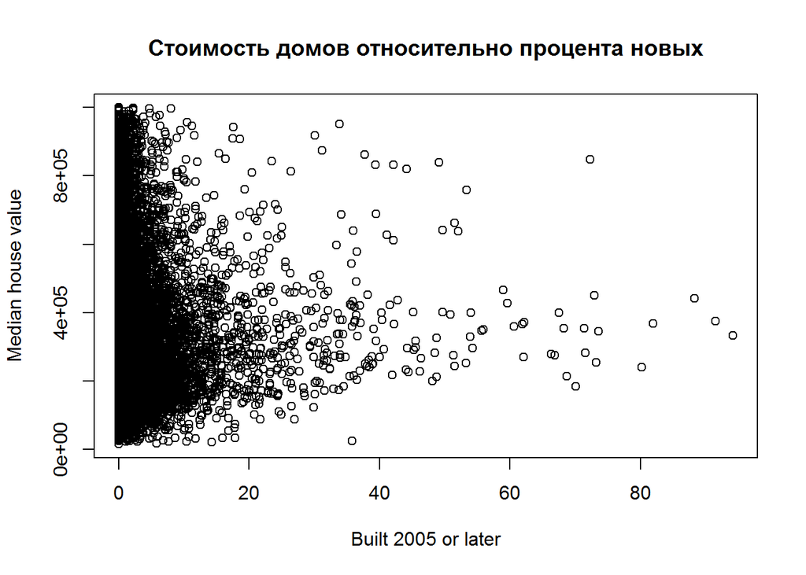

```r
Build_data = new[,"Built_2005_or_later"]
House_value = new[, "Median_house_value"]

plot(Build_data, House_value, main = "Cтоимость домов относительно процента новых", xlab ="Built 2005 or later", ylab = "Median house value" )
```

Отдельно для Калифорнии

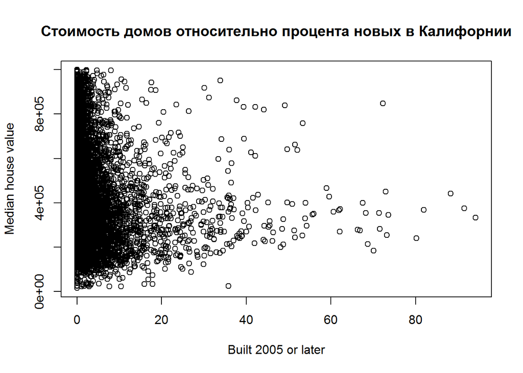

```r
Build_data_California = new$Built_2005_or_later[new$STATEFP==6]
House_value_California = new$Median_house_value[new$STATEFP==6]
plot(Build_data_California, House_value_California, main = "Cтоимость домов относительно процента новых в Калифорнии", xlab ="Built 2005 or later", ylab = "Median house value" )
```

Отдельно для Пенсильвании

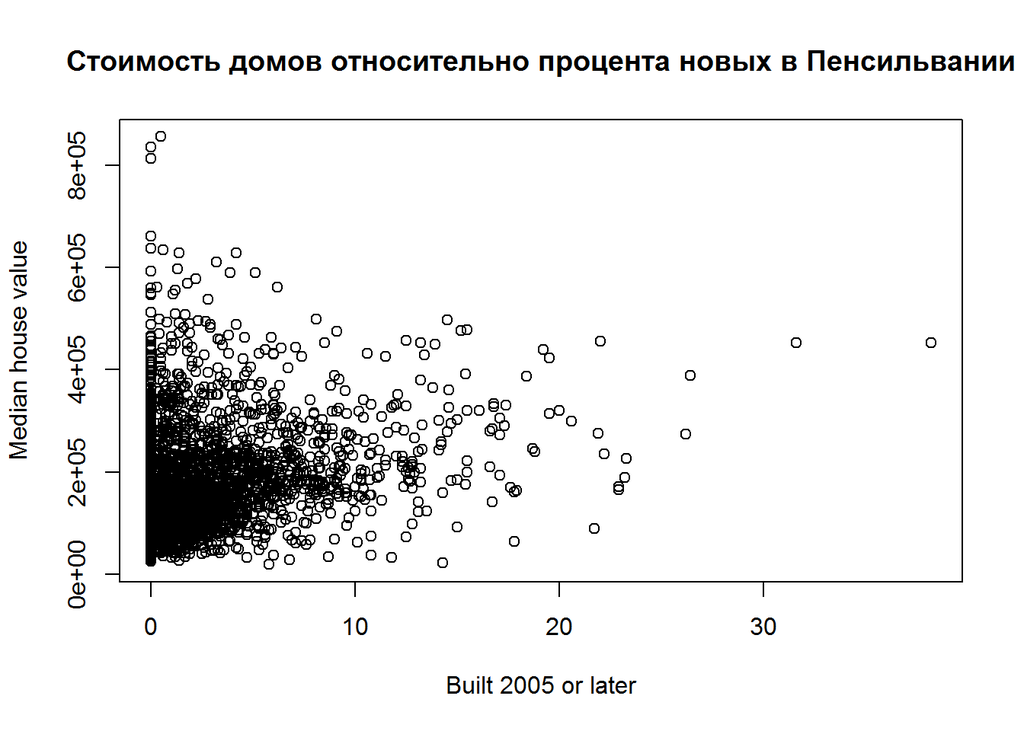

```r
Build_data_Pensilvania = new$Built_2005_or_later[new$STATEFP==42]
House_value_Pensilvania = new$Median_house_value[new$STATEFP==42]
plot(Build_data_Pensilvania, House_value_Pensilvania, main = "Cтоимость домов относительно процента новых в Пенсильвании", xlab ="Built 2005 or later", ylab = "Median house value" )
```

## Незанятые дома

В датафрейм data добавили новую колонку vacancy_rate

```r
data$vacancy_rate = data$Total_units/data$Vacant_units
```

Изменим отсутствующие значения

```r
data$vacancy_rate[data$vacancy_rate == Inf] = NaN
```

Находим максимум, минимум, среднее и медиану

```r
 max(data$vacancy_rate,na.rm=TRUE)
```

```
## [1] 409
```

```r
 min(data$vacancy_rate,na.rm=TRUE)
```

```
## [1] 1
```

```r
 mean(data$vacancy_rate,na.rm = TRUE)
```

```
## [1] 21.21474
```

```r
 median(data$vacancy_rate,na.rm = TRUE)
```

```
## [1] 14.13462
```

Постройте диаграмму уровня найма относительно медианы стоимости домов

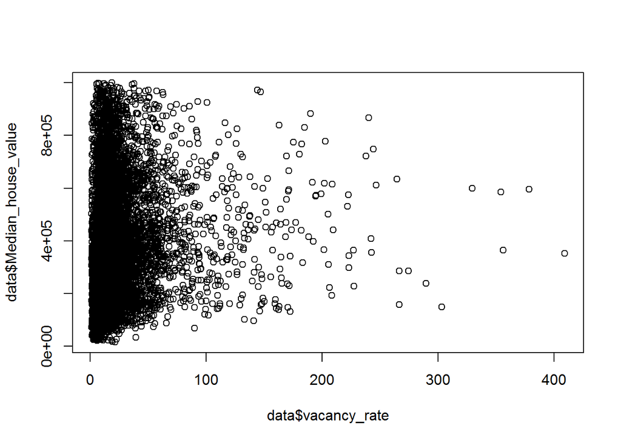

```r
plot (data$vacancy_rate, data$Median_house_value )
```

Заметно небольшое уменьшение количества свободных домов по мере увеличения медианы

## Корреляция

Код производит обход по датафрейму и выбирает штат Калифорния и округ 1, и добавляет номер строки в вектор. Далее цикл перебирает вектор acc и выбирает значения Median_house_value,которые попадают в вектор accmv и находится медиана

```r
acc <- c()
for (tract in 1:nrow(data)) {
  if (data$STATEFP[tract] == 6) {
    if (data$COUNTYFP[tract] == 1) {
      acc <- c(acc, tract)
    }
  }
}
accmv <- c()
for (tract in acc) {
  accmv <- c(accmv, data[tract,10])
}
median(accmv)
```

```
## [1] NA
```

То же самое, только короче

```r
MHV = subset(data, data$STATEFP==6, data$COUNTYFP==1, select = Median_house_value)
median(MHV)
```

```
## [1] NA
```

Найдите средний процент построенных домовладений в округах (Butte County, Santa Clara, York County)

```r
BC = subset(data, data$STATEFP==6 & data$COUNTYFP==7, select = Built_2005_or_later)
SC = subset(data, data$STATEFP==6 & data$COUNTYFP==85, select = Built_2005_or_later)
YC = subset(data, data$STATEFP==42 & data$COUNTYFP==133, select = Built_2005_or_later)
```

```r
mean(BC$Built_2005_or_late,na.rm=T)
```

```
## [1] 4.703922
```

```r
mean(SC$Built_2005_or_late,na.rm=T)
```

```
## [1] 3.160215
```

```r
mean(YC$Built_2005_or_later,na.rm=T)
```

```
## [1] 4.421111
```

Рассчитайте корреляцию между медианы стоимости домовладений (Median_house_value) и процентом построенных домов (Built_2005_or_later) для всего набора данных

```r
cor(data$Median_house_value, data$Built_2005_or_later, use = "pairwise.complete.obs")
```

```
## [1] -0.02052684
```

для Калифорнии

```r
cor (House_value_California, Build_data_California, use = "pairwise.complete.obs")
```

```
## [1] -0.1153604
```

Для Пенсильвании

```r
cor(House_value_Pensilvania, Build_data_Pensilvania, use = "pairwise.complete.obs")
```

```
## [1] 0.2681654
```

для округа Butte County

```r
Butte_County = subset(data, data$STATEFP==6 & data$COUNTYFP==7, select = Median_house_value)

cor(BC, Butte_County, use = "pairwise.complete.obs")
```

```
##                     Median_house_value
## Built_2005_or_later         0.04203267
```

для округа Santa Clara

```r
Santa_Clara = subset(data, data$STATEFP==6 & data$COUNTYFP==85, select = Median_house_value)
cor(SC, Santa_Clara, use = "pairwise.complete.obs")
```

```
##                     Median_house_value
## Built_2005_or_later         -0.1726203
```

для округа York County

```r
York_County = subset(data, data$STATEFP==42 & data$COUNTYFP==133, select = Median_house_value)
cor(YC,York_County, use = "pairwise.complete.obs")
```

```
##                     Median_house_value
## Built_2005_or_later          0.3860773
```

Постройте три диаграммы медианы стоимости домовладений (Median_house_value) относительно медианы дохода (Median_household_income) для трёх округов

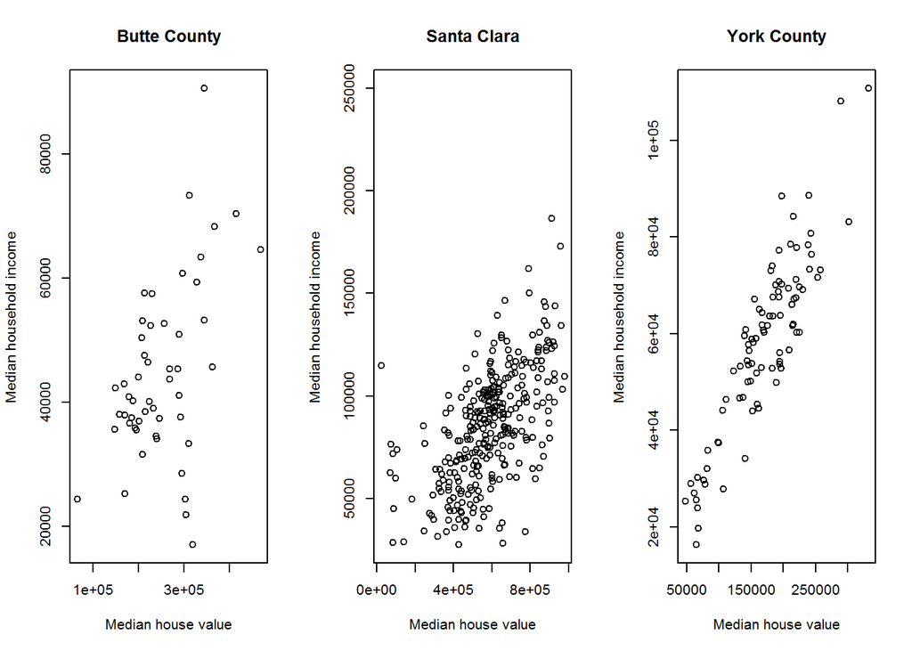

```r
MHIBC = subset(data, data$STATEFP==6 & data$COUNTYFP==7, select = Median_household_income)
MHISC = subset(data, data$STATEFP==6 & data$COUNTYFP==85, select = Median_household_income)
MHIYC = subset(data, data$STATEFP==42 & data$COUNTYFP==133, select = Median_household_income)

par(mfrow=c(1,3))

plot(Butte_County$Median_house_value,MHIBC$Median_household_income, main = "Butte County", xlab = "Median house value", ylab = "Median household income")
plot(Santa_Clara$Median_house_value,MHISC$Median_household_income, main = "Santa Clara", xlab = "Median house value", ylab = "Median household income")
plot(York_County$Median_house_value,MHIYC$Median_household_income, main = "York County", xlab = "Median house value", ylab = "Median household income")
```